# Modified Permanent Portfolio Asset Allocation

Jirong

2018-03-31T21:13:14-05:00

## An all weather portfolio

Based on the literature, permanent portfolio is an investment strategy that is able to yield moderate returns and relatively low volatility. Investor is recommended to invest 25% in equal proportion in GLD, Index, Bond and Cash and rebalance it to this proportion annually.

This approach is something that I’ve always been keen to adopt for a portion of my portfolio.

To investigate, I simulated a portfolio starting at $100 on Nov 2004. I modified the asset allocation proportion slightly by first eliminating the cash and distributed the % amongst the following tickers,

- AGG: US Bonds
- GLD: Gold
- GSPC: SnP 500

The portfolio is rebalanced yearly back to the same targeted proportion.

Note:

- I admit that the code that I wrote here is very procedural. If I’ve time, I’ll try to ‘functionalize’ the codes so that I could use it for other portfolio simulation purposes.
- The looping in the R vectorized setting is known to be super slow! If I really have time to spare, I’ll convert some of the loops to Rcpp (C++). But I highly doubt so since the data is not that huge at the moement (unless I venture into tick data. Oh well, who knows).

## Key points

On the annualized returns, it’s not really fantastic. But it still returns a respectable annualized performance of 5%; 1% lower than Gold and 0.5% higher than SnP 500 over the same period.

What stands out are the following performance metrics:

Feel free to adapt or adopt the code. You can easily substitue the stocks based on your preferred asset allocation.

## Setting up the analysis.

In this section, I downloaded stock data using quant mod. And merge the time series.

```r
library(quantmod)
```

```r
library(ggplot2)
library(PerformanceAnalytics)
library(tidyr)
library(dplyr)
library(tibble)

# Download data-->Fix the ending date for project section
ticker1 = "GLD"
stock1 = getSymbols(ticker1,from="1900-01-01",auto.assign=F)
```

[output not shown]

[output not shown]

```r
names(stock1) = c("open","high","low","close","volume","adj_close")
stock1 = stock1[,6]

ticker2 = "^GSPC"
stock2 = getSymbols(ticker2,from="1900-01-01",auto.assign=F)
names(stock2) = c("open","high","low","close","volume","adj_close")
stock2 = stock2[,6]

ticker3 = "AGG"
stock3 = getSymbols(ticker3,from="1900-01-01",auto.assign=F)
names(stock3) = c("open","high","low","close","volume","adj_close")
stock3 = stock3[,6]

# Merge the time series and subset NA
#These are the various time series
ticker_list = c("stock1","stock2","stock3")

#read in list. Loop through and assign variable to holder variable. Then assign it to combined list
ticker_all = get(ticker_list[1])

#Merging in the time series
for(i in 2:length(ticker_list)){
  ticker_ind = get(ticker_list[i])
  ticker_all = merge(ticker_all,ticker_ind)
}

names(ticker_all) = c("stock1","stock2","stock3")
```

## Running the simulation

Next, I run the simulation - By intialising 33% asset allocation in each of the asset and rebalance at end of each year. Daily portfolio returns are then obtained throught the ROC function.

```r
#Assign equal weights to each stream of returns
ticker_all = cbind(ticker_all,rowMeans(ticker_all))
ticker_all = subset(ticker_all,!is.na(ticker_all[,4]))
ticker_all = ticker_all[,-ncol(ticker_all)]

#Identify the period of rebalancing. Show the indexes
rebal_index = data.frame(index = endpoints(ticker_all,on="years")[-1])
# endpoints(ticker_all,on="quarters")

#Merge in the indicator into ticker_all--Can't seem to merge. Will do the inefficient loop
# merge(ticker_all,rebal_index, by = "index", all = T)
ticker_all$rebal = NA
for(i in 1:nrow(rebal_index)){
  ticker_all$rebal[rebal_index$index[i]] = 1
}

ticker_all$rebal = ifelse(is.na(ticker_all$rebal),0,ticker_all$rebal)

#Create the returns for each price series
ticker_all$ret1 = ROC(ticker_all[,1])
ticker_all$ret2 = ROC(ticker_all[,2])
ticker_all$ret3 = ROC(ticker_all[,3])

#Initialise value for each stock series, with a total portfolio value
ticker_all$val1 = NA; ticker_all$val1[1] = 100
ticker_all$val2 = NA; ticker_all$val2[1] = 100
ticker_all$val3 = NA; ticker_all$val3[1] = 100

ticker_all$portfolio_val = NA
ticker_all$portfolio_val[1] = rowSums(ticker_all[1,8:10])

#Loop each row and 'compound'. Till it reaches the rebalancing date. Then reset stock value amount in that day. Take the portfolio value in t-1
for(i in 2:nrow(ticker_all)){

  if(as.numeric(ticker_all$rebal[i]) == 0){

  #During non-rebalancing days
  ticker_all$val1[i] = as.numeric(ticker_all$val1[i-1]) * (1 + as.numeric(ticker_all$ret1[i]))
  ticker_all$val2[i] = as.numeric(ticker_all$val2[i-1]) * (1 + as.numeric(ticker_all$ret2[i]))
  ticker_all$val3[i] = as.numeric(ticker_all$val3[i-1]) * (1 + as.numeric(ticker_all$ret3[i]))

  ticker_all$portfolio_val[i] = rowSums(ticker_all[i,8:10])

  }else{
  #During re-balancing days
  ticker_all$val1[i] = ticker_all$portfolio_val[i-1] / 3
  ticker_all$val2[i] = ticker_all$portfolio_val[i-1] / 3
  ticker_all$val3[i] = ticker_all$portfolio_val[i-1] / 3

  ticker_all$portfolio_val[i] = rowSums(ticker_all[i,8:10])
  }
}

#Generate the daily portfolio returns
ticker_all$portfolio_ret = ROC(ticker_all[,11])
```

## Portfolio Performance for the entire period

On the annualized returns, it’s not really fantastic. But it still returns a respectable annualized performance of 5%; 1% lower than Gold and 0.5% higher than SnP 500 over the same period.

What stands out are the following performance metrics:

```r
######################################Study the portfolio returns########################################
#Carry out the portfolio return series
table.Drawdowns(ticker_all$portfolio_ret, top=10)
```

```
##          From     Trough         To   Depth Length To Trough Recovery
## 1  2008-02-29 2008-11-20 2010-05-11 -0.2597    554       186      368
## 2  2006-05-11 2006-06-14 2007-02-01 -0.1071    183        24      159
## 3  2012-10-05 2013-06-27 2014-06-30 -0.1040    434       181      253
## 4  2015-01-23 2016-01-19 2016-06-15 -0.0939    352       249      103
## 5  2011-09-06 2011-10-04 2012-02-02 -0.0702    104        21       83
## 6  2016-08-19 2016-12-15 2017-05-26 -0.0675    194        83      111
## 7  2012-02-29 2012-05-16 2012-09-07 -0.0605    134        55       79
## 8  2010-05-13 2010-07-06 2010-09-14 -0.0479     86        37       49
## 9  2018-01-29 2018-02-08       <NA> -0.0479     44         9       NA
## 10 2007-05-08 2007-08-16 2007-09-11 -0.0434     88        71       17
```

```r
table.DownsideRisk(merge(ticker_all$portfolio_ret, ticker_all$ret1, ticker_all$ret2, ticker_all$ret3))
```

```
##                               portfolio_ret    ret1    ret2    ret3
## Semi Deviation                       0.0042  0.0087  0.0087  0.0023
## Gain Deviation                       0.0037  0.0079  0.0084  0.0021
## Loss Deviation                       0.0045  0.0090  0.0100  0.0026
## Downside Deviation (MAR=210%)        0.0098  0.0135  0.0134  0.0087
## Downside Deviation (Rf=0%)           0.0041  0.0085  0.0086  0.0022
## Downside Deviation (0%)              0.0041  0.0085  0.0086  0.0022
## Maximum Drawdown                     0.2597  0.4922  0.6103  0.1313
## Historical VaR (95%)                -0.0087 -0.0188 -0.0179 -0.0038
## Historical ES (95%)                 -0.0136 -0.0287 -0.0300 -0.0064
## Modified VaR (95%)                  -0.0091 -0.0189 -0.0177 -0.0008
## Modified ES (95%)                   -0.0195 -0.0341 -0.0302 -0.0008
```

```r
table.AnnualizedReturns(merge(ticker_all$portfolio_ret, ticker_all$ret1, ticker_all$ret2, ticker_all$ret3))
```

```
##                           portfolio_ret   ret1   ret2   ret3
## Annualized Return                0.0491 0.0620 0.0432 0.0363
## Annualized Std Dev               0.0899 0.1893 0.1885 0.0482
## Annualized Sharpe (Rf=0%)        0.5464 0.3274 0.2294 0.7535
```

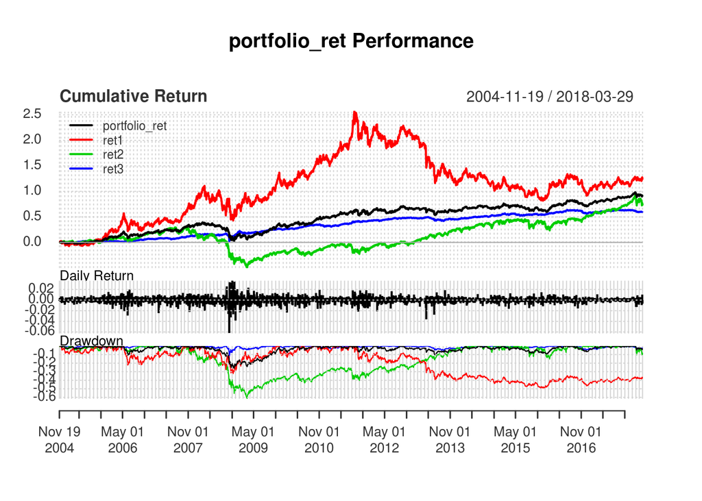

```r
charts.PerformanceSummary(merge(ticker_all$portfolio_ret, ticker_all$ret1, ticker_all$ret2, ticker_all$ret3))
```

## Yearly Portfolio Performance

I also tabulated the yearly metrics of the portfolio to give a sense of the performance over years.

```r
#####################################Study the annualized portfolio returns series#######################
#Use the rebal-indicator. Loop through the chunks
# https://www.quantmod.com/documentation/periodReturn.html
# https://rpubs.com/mohammadshadan/288218
# yearly_ret = periodReturn(ticker_all$portfolio_val
#              ,period='yearly',subset='2004::')  # returns years 2003 to present

yearly_ret = periodReturn(ticker_all$portfolio_val
                          ,period='yearly')  # returns years 2003 to present

#Inefficient way to calulate standard deviation. If it've time, I will probably optimize this
split_val = split(ticker_all$portfolio_ret, f = "years")
yearly_ret$annual_sd = sapply(X = split_val, FUN = StdDev) * sqrt(252)


getSymbols('DGS3MO',src = 'FRED')
```

```
## [1] "DGS3MO"
```

```r
rf = DGS3MO; rm(DGS3MO)
rf = rf["2004/2018"]

split_val_rf = split(rf$DGS3MO, f = "years")
yearly_ret$annual_rf = sapply(X = split_val_rf, FUN = mean, na.rm = T)/100

yearly_ret$Sharpe = (yearly_ret$yearly.returns - yearly_ret$annual_rf)/yearly_ret$annual_sd

yearly_ret
```

```
##            yearly.returns  annual_sd    annual_rf     Sharpe
## 2004-12-31    0.004226944 0.05540773 0.0139872000 -0.1761533
## 2005-12-30    0.072086547 0.05645463 0.0321612000  0.7072112
## 2006-12-29    0.119531756 0.10051348 0.0485156000  0.7065336
## 2007-12-31    0.128879475 0.09157342 0.0448095618  0.9180602
## 2008-12-31   -0.128296533 0.16426474 0.0139685259 -0.8660718
## 2009-12-31    0.146831877 0.11599763 0.0015092000  1.2528072
## 2010-12-31    0.142566228 0.08892810 0.0013844622  1.5875945
## 2011-12-30    0.038641897 0.09995615 0.0005284000  0.3813022
## 2012-12-31    0.063250462 0.07334484 0.0008760000  0.8504275
## 2013-12-31   -0.013798292 0.08392775 0.0005708000 -0.1712079
## 2014-12-31    0.052948032 0.05736776 0.0003272000  0.9172544
## 2015-12-31   -0.041404619 0.06912477 0.0005250996 -0.6065802
## 2016-12-30    0.061886147 0.06319037 0.0031936000  0.9288211
## 2017-12-29    0.115604533 0.04028321 0.0094896000  2.6342224
## 2018-03-29   -0.010810745 0.08058259 0.0158213115 -0.3304939
```

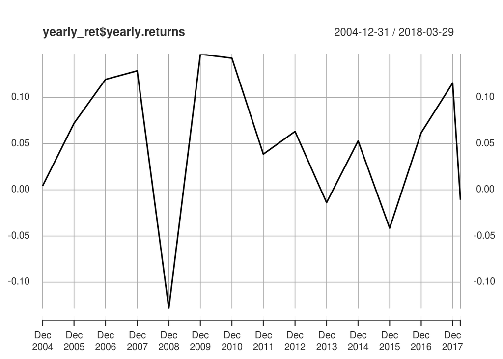

```r
plot(yearly_ret$yearly.returns)
```

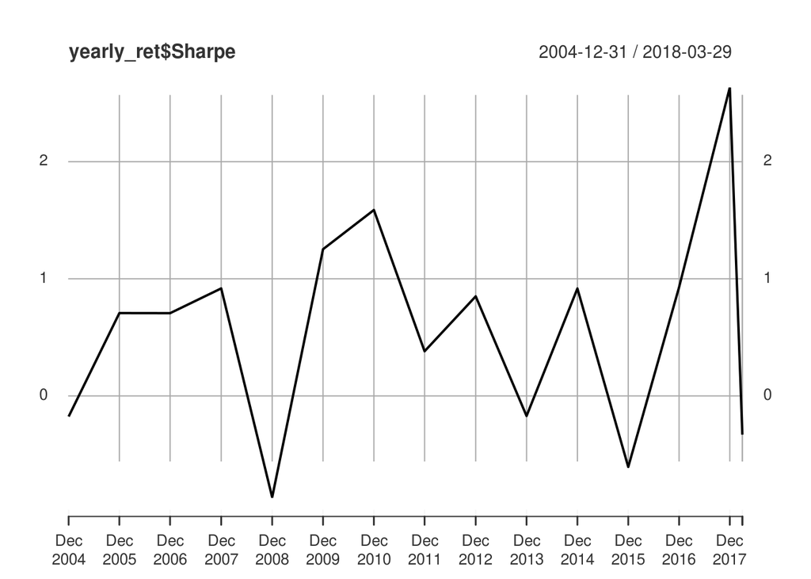

```r
plot(yearly_ret$Sharpe)
```